# Hitter Development Report

← Team overview · League overview

# Lenyn Sosa

**2026 season · Profile: Balanced · xwOBA 0.249 (1st percentile)**

**Small sample:** 217 competitive swings in 2026. Bat speed stabilises quickly, but contact and outcome metrics should be read as early signals, not conclusions.

Lenyn Sosa squares up the ball at a below-average rate (36th percentile) with bat speed in the 53rd percentile. Main lever: **better swing decisions – chase less.**

## Swing profile vs MLB

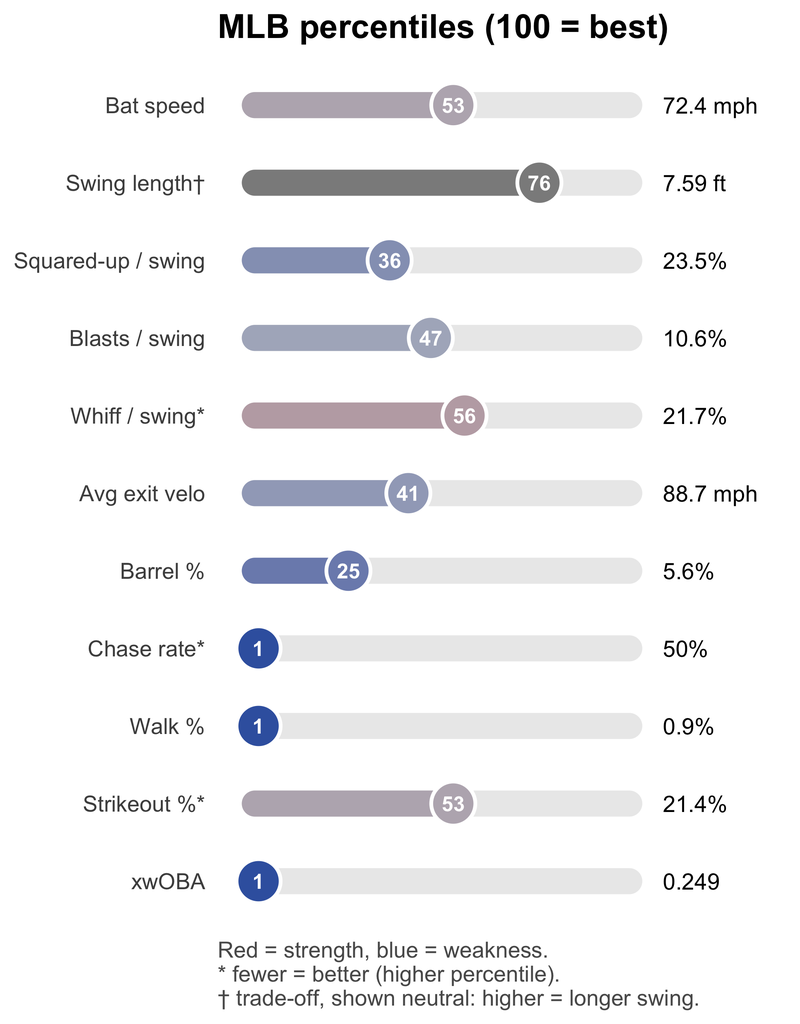

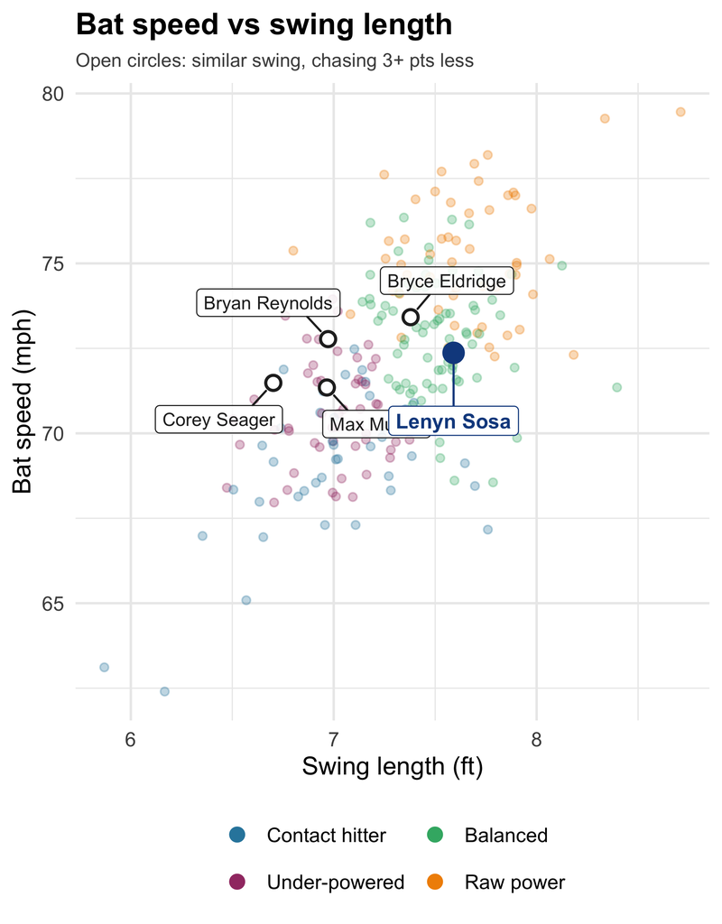

## Year-over-year

| Season | Bat speed (mph) | Swing length (ft) | Squared-up / swing | Whiff / swing | xwOBA | wOBA (actual) |
| --- | --- | --- | --- | --- | --- | --- |
| 2025 | 72.5 | 7.42 | 27.0% | 21.8% | 0.326 | 0.313 |
| 2026 | 72.4 | 7.59 | 23.5% | 21.7% | 0.249 | 0.214 |
| Change | -0.2 | +0.17 | -3.5 pts | -0.1 pts | -0.077 | -0.099 |

**From 2025 to 2026:** bat speed stayed flat, squared-up rate fell 3.5 pts and xwOBA fell 77 points.

Actual wOBA fell short of xwOBA in both seasons (-13, -35 pts): results may understate his contact quality – to verify with spray-chart and batted-ball data.

## What the model says

Across 232 qualified MLB hitters in 2026, at equal swing length, contact and whiff rate, **+1 mph of bat speed is associated with +10 points of xwOBA**, and +1 point of squared-up rate with +4 points. The swing metrics explain 42% of the differences in production between hitters; adding swing decisions (chase and in-zone swing rates) raises it to 47%. The rest comes from timing, launch direction and factors public data does not capture.

These are cross-sectional associations, not guarantees: they set the hypothesis to test with the player, not the expected outcome.

## Development plan

**Diagnosis.** Lenyn Sosa’s swing is sound (53rd percentile in bat speed, 36th in squared-up rate), but he chases 50% of pitches outside the zone (1st percentile): too many swings go to pitches he cannot damage.

**Priority.** Improve swing decisions without losing aggressiveness in the zone.

1. **Screen** – Chase by pitch type, location and count (two-strike approach).
2. **Intervene** – Pitch-recognition and decision training with the hitting coaches (video, constraint-based BP).
3. **Monitor** – Chase rate and in-zone swing rate each week; bat speed protected.

Reference points – similar swing, chasing 3+ pts less

| Comparable hitter | Bat speed (mph) | Squared-up / swing | xwOBA |
| --- | --- | --- | --- |
| Bryce Eldridge | 73.4 | 23.8% | 0.359 |
| Bryan Reynolds | 72.8 | 24.7% | 0.355 |
| Corey Seager | 71.5 | 26.3% | 0.350 |
| Max Muncy | 71.3 | 24.9% | 0.349 |

Data: Baseball Savant, public Statcast data (bat tracking, expected stats, exit velocity). Bat speed = average of the top 90% of competitive swings. Percentiles (1–100), model and profiles are based on the 232 qualified MLB hitters in 2026 (570+ competitive swings). Profiles: k-means on bat speed, swing length, squared-up and whiff rates. Internal biomechanics data would replace the screening hypotheses with measured values. Report: Hugo Leligny.

Hugo Leligny · Sport Scientist & Performance Analyst  
Measure → Analyze → Decide → Train → Monitor → Adapt ↻  
hugoleligny14@gmail.com · [GitHub](https://github.com/hugollel/blue-jays-hitting)